# PREDICTING A PULSAR STAR

https://www.kaggle.com/pavanraj159/predicting-a-pulsar-star/home

HTRU2 is a data set which describes a sample of pulsar candidates collected during the High Time Resolution Universe Survey.

Pulsars are a rare type of Neutron star that produce radio emission detectable here on Earth. They are of considerable scientific interest as probes of space-time, the inter-stellar medium, and states of matter .

As pulsars rotate, their emission beam sweeps across the sky, and when this crosses our line of sight, produces a detectable pattern of broadband radio emission. As pulsars rotate rapidly, this pattern repeats periodically. Thus pulsar search involves looking for periodic radio signals with large radio telescopes.

Each pulsar produces a slightly different emission pattern, which varies slightly with each rotation . Thus a potential signal detection known as a 'candidate', is averaged over many rotations of the pulsar, as determined by the length of an observation. In the absence of additional info, each candidate could potentially describe a real pulsar. However in practice almost all detections are caused by radio frequency interference (RFI) and noise, making legitimate signals hard to find.

Machine learning tools are now being used to automatically label pulsar candidates to facilitate rapid analysis. Classification systems in particular are being widely adopted, which treat the candidate data sets as binary classification problems. Here the legitimate pulsar examples are a minority positive class, and spurious examples the majority negative class.

The data set shared here contains 16,259 spurious examples caused by RFI/noise, and 1,639 real pulsar examples. These examples have all been checked by human annotators.

Each row lists the variables first, and the class label is the final entry. The class labels used are 0 (negative) and 1 (positive).

# Attribute Information:

Each candidate is described by 8 continuous variables, and a single class variable. The first four are simple statistics obtained from the integrated pulse profile (folded profile). This is an array of continuous variables that describe a longitude-resolved version of the signal that has been averaged in both time and frequency . The remaining four variables are similarly obtained from the DM-SNR curve . These are summarised below:

Mean of the integrated profile. Standard deviation of the integrated profile. Excess kurtosis of the integrated profile. Skewness of the integrated profile. Mean of the DM-SNR curve. Standard deviation of the DM-SNR curve. Excess kurtosis of the DM-SNR curve. Skewness of the DM-SNR curve. Class HTRU 2 Summary 17,898 total examples. 1,639 positive examples. 16,259 negative examples.

# The data set contains information we’ll use to predict whether or not is a pulsar star

```python
import pandas as pd
import numpy as np
import matplotlib.pyplot as plt
import seaborn as sns
```

```python
pulsar = pd.read_csv("~/Downloads/pulsar_stars.csv")
```

```python
pulsar.head()
```

|  | Mean of the integrated profile | Standard deviation of the integrated profile | Excess kurtosis of the integrated profile | Skewness of the integrated profile | Mean of the DM-SNR curve | Standard deviation of the DM-SNR curve | Excess kurtosis of the DM-SNR curve | Skewness of the DM-SNR curve | target_class |
| --- | --- | --- | --- | --- | --- | --- | --- | --- | --- |
| 0 | 140.562500 | 55.683782 | -0.234571 | -0.699648 | 3.199833 | 19.110426 | 7.975532 | 74.242225 | 0 |
| 1 | 102.507812 | 58.882430 | 0.465318 | -0.515088 | 1.677258 | 14.860146 | 10.576487 | 127.393580 | 0 |
| 2 | 103.015625 | 39.341649 | 0.323328 | 1.051164 | 3.121237 | 21.744669 | 7.735822 | 63.171909 | 0 |
| 3 | 136.750000 | 57.178449 | -0.068415 | -0.636238 | 3.642977 | 20.959280 | 6.896499 | 53.593661 | 0 |
| 4 | 88.726562 | 40.672225 | 0.600866 | 1.123492 | 1.178930 | 11.468720 | 14.269573 | 252.567306 | 0 |

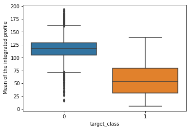

```python
# Mean of Integrated Profile Vs Target Variable
sns.boxplot(x = "target_class", y = " Mean of the integrated profile", data = pulsar)
```

### Median of Integrated Profile with Negative Class Pulsar is higher than Positive Pulsar Class

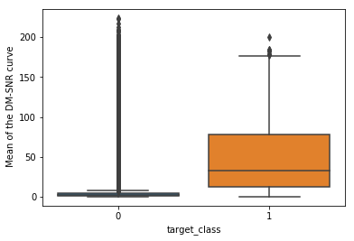

```python
# Mean of the DM-SNR curve Vs Target Variable
sns.boxplot(x = "target_class", y = " Mean of the DM-SNR curve", data = pulsar)
```

The median of DM SNR Curve is higher for Positive Target Class in comparison to the Negative Class.

```python
pulsar.shape[1] # Total 09 Columns
```

```
9
```

```python
# Apply Min Max Scaler so that the values range between 0 and 1
from sklearn.preprocessing import MinMaxScaler
```

```python
mmx = MinMaxScaler()
```

```python
newpulsar = mmx.fit_transform(pulsar.drop("target_class", axis = 1))
```

```python
newpulsar = pd.DataFrame(newpulsar, columns=pulsar.columns[:8])
```

```python
# Applying PCA
from sklearn.decomposition import PCA
pca = PCA(n_components=5)
```

```python
pcavalues = pca.fit_transform(newpulsar)
```

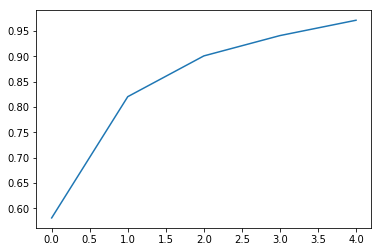

```python
plt.plot(np.cumsum(pca.explained_variance_ratio_))
```

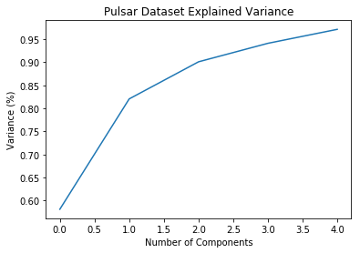

```python
plt.figure()
plt.plot(np.cumsum(pca.explained_variance_ratio_))
plt.xlabel('Number of Components')
plt.ylabel('Variance (%)') #for each component
plt.title('Pulsar Dataset Explained Variance')
plt.show()
```

# Taking Standard Scaler and then Applying PCA

## Purpose - To see if the N components change

```python
from sklearn.preprocessing import StandardScaler
sc = StandardScaler()
```

```python
pulsar_scaled = sc.fit_transform(pulsar.drop("target_class", axis=1))
```

```python
pulsar_scaled = pd.DataFrame(pulsar_scaled,columns=pulsar.columns[:8])
```

```python
pulsar_scaled.head()
```

|  | Mean of the integrated profile | Standard deviation of the integrated profile | Excess kurtosis of the integrated profile | Skewness of the integrated profile | Mean of the DM-SNR curve | Standard deviation of the DM-SNR curve | Excess kurtosis of the DM-SNR curve | Skewness of the DM-SNR curve |
| --- | --- | --- | --- | --- | --- | --- | --- | --- |
| 0 | 1.149317 | 1.334832 | -0.669570 | -0.400459 | -0.319440 | -0.370625 | -0.072798 | -0.287438 |
| 1 | -0.334168 | 1.802265 | -0.011785 | -0.370535 | -0.371102 | -0.588924 | 0.504427 | 0.211581 |
| 2 | -0.314372 | -1.053322 | -0.145233 | -0.116593 | -0.322107 | -0.235328 | -0.125996 | -0.391373 |
| 3 | 1.000694 | 1.553254 | -0.513409 | -0.390178 | -0.304404 | -0.275666 | -0.312265 | -0.481300 |
| 4 | -0.871402 | -0.858879 | 0.115609 | -0.104866 | -0.388010 | -0.763111 | 1.324026 | 1.386794 |

```python
# Applying PCA and finding the n components
#pca = PCA(n_components=5)
#p = pca.fit_transform(pulsar_scaled)
```

[figure not shown]

```python
plt.plot(np.cumsum(pca.explained_variance_ratio_), color = "darkblue",
         linestyle = "dashed", marker = "o", markerfacecolor = "red",
         markersize = 8)
```

```python
np.cumsum(pca.explained_variance_ratio_)
```

[output not shown]

```python
# Added Target Variable
pulsar_scaled["target"] = pulsar.target_class
```

```python
x = pulsar_scaled.drop("target", axis = 1)
y = pulsar_scaled.target
```

```python
# Split the Data in X and Y
from sklearn.cross_validation import train_test_split
xtrain,xtest,ytrain,ytest = train_test_split(x, y, test_size = 0.30, random_state = 0)
```

```python
#Lets Apply ML - Decision Tree
from sklearn.tree import DecisionTreeClassifier
from sklearn.metrics import accuracy_score
tree = DecisionTreeClassifier()
```

```python
tree.fit(xtrain, ytrain)
```

```
DecisionTreeClassifier(class_weight=None, criterion='gini', max_depth=None,
            max_features=None, max_leaf_nodes=None,
            min_impurity_decrease=0.0, min_impurity_split=None,
            min_samples_leaf=1, min_samples_split=2,
            min_weight_fraction_leaf=0.0, presort=False, random_state=None,
            splitter='best')
```

```python
model_tree = tree.predict(xtest)
```

```python
accuracy_score(ytest,model_tree) # 0.9674115456238361 on 6 PCA, 96.9% on 5 PCA
```

```
0.9681564245810056
```

```python
from sklearn.ensemble import RandomForestClassifier
rc = RandomForestClassifier()
```

```python
rc.fit(xtrain,ytrain)
```

```
RandomForestClassifier(bootstrap=True, class_weight=None, criterion='gini',
            max_depth=None, max_features='auto', max_leaf_nodes=None,
            min_impurity_decrease=0.0, min_impurity_split=None,
            min_samples_leaf=1, min_samples_split=2,
            min_weight_fraction_leaf=0.0, n_estimators=10, n_jobs=1,
            oob_score=False, random_state=None, verbose=0,
            warm_start=False)
```

```python
accuracy_score(ytest,rc.predict(xtest)) # 0.9806 with 05 principal components
```

```
0.9791433891992551
```

```python
# Apply SVM
from sklearn.svm import SVC
svm = SVC()
```

```python
svm.fit(xtrain, ytrain)
```

```
SVC(C=1.0, cache_size=200, class_weight=None, coef0=0.0,
  decision_function_shape='ovr', degree=3, gamma='auto', kernel='rbf',
  max_iter=-1, probability=False, random_state=None, shrinking=True,
  tol=0.001, verbose=False)
```

```python
accuracy_score(ytest, svm.predict(xtest))
```

```
0.9791433891992551
```

# Support Vector Machines

SVM generates a line that divides the data in two parts or more. Basically its a line of demarcation between the points.

```python
import pandas as pd
import matplotlib.pyplot as plt
import numpy as np
import seaborn as sns
```

## Loading and Preparing the Dataset - Breast Cancer

```python
from sklearn.datasets import load_breast_cancer
bc = load_breast_cancer()
```

```python
# Importing the Dataset
cancer = pd.DataFrame(bc.data, columns=bc.feature_names)
```

```python
# Adding the Target Variable
cancer["target"] = bc.target
```

```python
cancer.columns
```

```
Index(['mean radius', 'mean texture', 'mean perimeter', 'mean area',
       'mean smoothness', 'mean compactness', 'mean concavity',
       'mean concave points', 'mean symmetry', 'mean fractal dimension',
       'radius error', 'texture error', 'perimeter error', 'area error',
       'smoothness error', 'compactness error', 'concavity error',
       'concave points error', 'symmetry error', 'fractal dimension error',
       'worst radius', 'worst texture', 'worst perimeter', 'worst area',
       'worst smoothness', 'worst compactness', 'worst concavity',
       'worst concave points', 'worst symmetry', 'worst fractal dimension',
       'target'],
      dtype='object')
```

```python
# Print the Cancer Description
print(bc.DESCR)
```

```
Breast Cancer Wisconsin (Diagnostic) Database
=============================================

Notes
-----
Data Set Characteristics:
    :Number of Instances: 569

    :Number of Attributes: 30 numeric, predictive attributes and the class

    :Attribute Information:
        - radius (mean of distances from center to points on the perimeter)
        - texture (standard deviation of gray-scale values)
        - perimeter
        - area
        - smoothness (local variation in radius lengths)
        - compactness (perimeter^2 / area - 1.0)
        - concavity (severity of concave portions of the contour)
        - concave points (number of concave portions of the contour)
        - symmetry
        - fractal dimension ("coastline approximation" - 1)

        The mean, standard error, and "worst" or largest (mean of the three
        largest values) of these features were computed for each image,
        resulting in 30 features.  For instance, field 3 is Mean Radius, field
        13 is Radius SE, field 23 is Worst Radius.

        - class:
                - WDBC-Malignant
                - WDBC-Benign

    :Summary Statistics:

    ===================================== ====== ======
                                           Min    Max
    ===================================== ====== ======
    radius (mean):                        6.981  28.11
    texture (mean):                       9.71   39.28
    perimeter (mean):                     43.79  188.5
    area (mean):                          143.5  2501.0
```

[output cut: 62 more lines]

```
ftp ftp.cs.wisc.edu
cd math-prog/cpo-dataset/machine-learn/WDBC/

References
----------
   - W.N. Street, W.H. Wolberg and O.L. Mangasarian. Nuclear feature extraction
     for breast tumor diagnosis. IS&T/SPIE 1993 International Symposium on
     Electronic Imaging: Science and Technology, volume 1905, pages 861-870,
     San Jose, CA, 1993.
   - O.L. Mangasarian, W.N. Street and W.H. Wolberg. Breast cancer diagnosis and
     prognosis via linear programming. Operations Research, 43(4), pages 570-577,
     July-August 1995.
   - W.H. Wolberg, W.N. Street, and O.L. Mangasarian. Machine learning techniques
     to diagnose breast cancer from fine-needle aspirates. Cancer Letters 77 (1994)
     163-171.
```

```python
# Define the Info and shape of the dataset
cancer.info()
```

```
<class 'pandas.core.frame.DataFrame'>
RangeIndex: 569 entries, 0 to 568
Data columns (total 31 columns):
mean radius                569 non-null float64
mean texture               569 non-null float64
mean perimeter             569 non-null float64
mean area                  569 non-null float64
mean smoothness            569 non-null float64
mean compactness           569 non-null float64
mean concavity             569 non-null float64
mean concave points        569 non-null float64
mean symmetry              569 non-null float64
mean fractal dimension     569 non-null float64
radius error               569 non-null float64
texture error              569 non-null float64
perimeter error            569 non-null float64
area error                 569 non-null float64
smoothness error           569 non-null float64
compactness error          569 non-null float64
concavity error            569 non-null float64
concave points error       569 non-null float64
symmetry error             569 non-null float64
fractal dimension error    569 non-null float64
worst radius               569 non-null float64
worst texture              569 non-null float64
worst perimeter            569 non-null float64
worst area                 569 non-null float64
worst smoothness           569 non-null float64
worst compactness          569 non-null float64
worst concavity            569 non-null float64
worst concave points       569 non-null float64
worst symmetry             569 non-null float64
worst fractal dimension    569 non-null float64
target                     569 non-null int64
dtypes: float64(30), int64(1)
memory usage: 137.9 KB
```

```python
# Defining the x and y variable from the dataset
x = cancer.drop("target", axis = 1)
y = cancer.target
```

```python
# Do the Train Test Split and Import SVM
from sklearn.cross_validation import train_test_split
xt,xte,yt,yte = train_test_split(x, y, test_size = 0.30, random_state = 101)
```

```python
# Import SVM Classifier
from sklearn.svm import SVC
svm = SVC()
```

```python
svm.fit(xt, yt)
```

```
SVC(C=1.0, cache_size=200, class_weight=None, coef0=0.0,
  decision_function_shape='ovr', degree=3, gamma='auto', kernel='rbf',
  max_iter=-1, probability=False, random_state=None, shrinking=True,
  tol=0.001, verbose=False)
```

```python
accuracy_score(yte,svm.predict(xte))
```

```
0.6140350877192983
```

# Finally the Objective is to scale the data and PCA it and then apply SVM.

```python
# Scaling the cancer data
from sklearn.preprocessing import StandardScaler
sc = StandardScaler()
```

```python
scaled_cancer = pd.DataFrame(sc.fit_transform(cancer), columns=cancer.columns)
x = scaled_cancer.drop("target", axis = 1)
y = cancer.target # It will be 0 and 1. The target variable should not be scaled as it will throw the error
# of being CONTINUOUS.
```

```python
xtrr,xtes,ytrr,ytes = train_test_split(x,y, test_size = 0.30, random_state = 101)
```

```python
svm.fit(xtrr, ytrr)
```

```
SVC(C=1.0, cache_size=200, class_weight=None, coef0=0.0,
  decision_function_shape='ovr', degree=3, gamma='auto', kernel='rbf',
  max_iter=-1, probability=False, random_state=None, shrinking=True,
  tol=0.001, verbose=False)
```

```python
accuracy_score(ytes, svm.predict(xtes))
```

```
0.9766081871345029
```

# Lets Try PCA and lets Apply SVM post that.

The data used will be scaled_cancer

```python
scaled_cancer.head()
```

|  | mean radius | mean texture | mean perimeter | mean area | mean smoothness | mean compactness | mean concavity | mean concave points | mean symmetry | mean fractal dimension | ... | worst texture | worst perimeter | worst area | worst smoothness | worst compactness | worst concavity | worst concave points | worst symmetry | worst fractal dimension | target |
| --- | --- | --- | --- | --- | --- | --- | --- | --- | --- | --- | --- | --- | --- | --- | --- | --- | --- | --- | --- | --- | --- |
| 0 | 1.097064 | -2.073335 | 1.269934 | 0.984375 | 1.568466 | 3.283515 | 2.652874 | 2.532475 | 2.217515 | 2.255747 | ... | -1.359293 | 2.303601 | 2.001237 | 1.307686 | 2.616665 | 2.109526 | 2.296076 | 2.750622 | 1.937015 | -1.297676 |
| 1 | 1.829821 | -0.353632 | 1.685955 | 1.908708 | -0.826962 | -0.487072 | -0.023846 | 0.548144 | 0.001392 | -0.868652 | ... | -0.369203 | 1.535126 | 1.890489 | -0.375612 | -0.430444 | -0.146749 | 1.087084 | -0.243890 | 0.281190 | -1.297676 |
| 2 | 1.579888 | 0.456187 | 1.566503 | 1.558884 | 0.942210 | 1.052926 | 1.363478 | 2.037231 | 0.939685 | -0.398008 | ... | -0.023974 | 1.347475 | 1.456285 | 0.527407 | 1.082932 | 0.854974 | 1.955000 | 1.152255 | 0.201391 | -1.297676 |
| 3 | -0.768909 | 0.253732 | -0.592687 | -0.764464 | 3.283553 | 3.402909 | 1.915897 | 1.451707 | 2.867383 | 4.910919 | ... | 0.133984 | -0.249939 | -0.550021 | 3.394275 | 3.893397 | 1.989588 | 2.175786 | 6.046041 | 4.935010 | -1.297676 |
| 4 | 1.750297 | -1.151816 | 1.776573 | 1.826229 | 0.280372 | 0.539340 | 1.371011 | 1.428493 | -0.009560 | -0.562450 | ... | -1.466770 | 1.338539 | 1.220724 | 0.220556 | -0.313395 | 0.613179 | 0.729259 | -0.868353 | -0.397100 | -1.297676 |

5 rows × 31 columns

```python
# Lets Apply PCA
from sklearn.decomposition import PCA
pca = PCA(n_components=20)
```

```python
pca_cancer = pd.DataFrame(pca.fit_transform(scaled_cancer))
x = pca_cancer
y = cancer.target
```

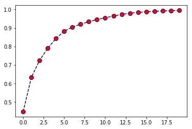

```python
# Lets Find the Optimum no of Components required for the SVM
plt.plot(np.cumsum(pca.explained_variance_ratio_), color = "darkblue",
         linestyle = "dashed", marker = "o", markerfacecolor = "red",
         markersize = 8)
```

```python
sctrain,sctest,ysctrain,ysctest=train_test_split(x,y, test_size = 0.30, random_state = 101)
```

```python
svm.fit(sctrain,ysctrain)
```

```
SVC(C=1.0, cache_size=200, class_weight=None, coef0=0.0,
  decision_function_shape='ovr', degree=3, gamma='auto', kernel='rbf',
  max_iter=-1, probability=False, random_state=None, shrinking=True,
  tol=0.001, verbose=False)
```

```python
accuracy_score(ysctest,svm.predict(sctest)) # 99.4% Accuracy on 20 PCA
```

```
0.9941520467836257
```

```python
cancer.target.value_counts()
```

```
1    357
0    212
Name: target, dtype: int64
```

# Another Dataset resembling the breast cancer prediction problem

```python
import numpy as np
import pandas as pd
from sklearn.svm import SVC
```

```python
bc = pd.read_csv("~/Downloads/bc2.csv")
```

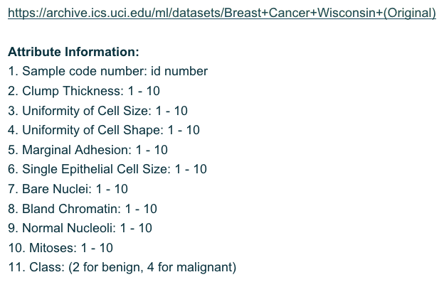

```python
bc.columns
```

```
Index(['ID', 'ClumpThickness', 'Cell Size', 'Cell Shape', 'Marginal Adhesion',
       'Single Epithelial Cell Size', 'Bare Nuclei', 'Normal Nucleoli',
       'Bland Chromatin', 'Mitoses', 'Class'],
      dtype='object')
```

```python
# Find the count of ?
# step1. find the list of Column names
print(bc.columns)

# step2 put them in loop
for i in ['Bare Nuclei']:
    print(i, "is", sum(bc[i]== "?"))

# This kinda problem exists in Object Variables Only
```

```
Index(['ID', 'ClumpThickness', 'Cell Size', 'Cell Shape', 'Marginal Adhesion',
       'Single Epithelial Cell Size', 'Bare Nuclei', 'Normal Nucleoli',
       'Bland Chromatin', 'Mitoses', 'Class'],
      dtype='object')
Bare Nuclei is 16
```

# Missing Values in the dataset

```python
# Replace ? with nan
bc = bc.replace(to_replace="?", value=np.nan)
```

```python
# Check the count of Missing Values
bc.isnull().sum()
```

```
ID                              0
ClumpThickness                  0
Cell Size                       0
Cell Shape                      0
Marginal Adhesion               0
Single Epithelial Cell Size     0
Bare Nuclei                    16
Normal Nucleoli                 0
Bland Chromatin                 0
Mitoses                         0
Class                           0
dtype: int64
```

```python
newbc = bc.apply(lambda x:x.fillna(x.median()), axis = 1)
```

```python
newbc.isnull().sum()
```

```
ID                             0
ClumpThickness                 0
Cell Size                      0
Cell Shape                     0
Marginal Adhesion              0
Single Epithelial Cell Size    0
Bare Nuclei                    0
Normal Nucleoli                0
Bland Chromatin                0
Mitoses                        0
Class                          0
dtype: int64
```

```python
bc["Bare Nuclei"] = bc["Bare Nuclei"].astype("float64")
```

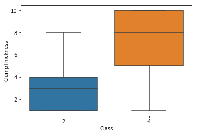

```python
import matplotlib.pyplot as plt
import seaborn as sns
sns.boxplot(x = "Class", y = "ClumpThickness", data = bc)
plt.show()

# This shows that the class 4 is chronic and more fatal
```

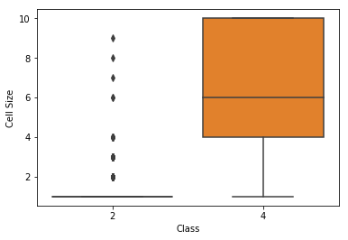

```python
sns.boxplot(x = "Class", y = "Cell Size", data = bc)
plt.show()
# Cell Size of class 4 is higher than the size 02
```

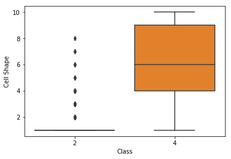

```python
sns.boxplot(x = "Class", y = "Cell Shape", data = bc)
plt.show()
# Cell Shape of class 4 is bigger than the size 02
```

```python
bc.describe().T
```

[output not shown]

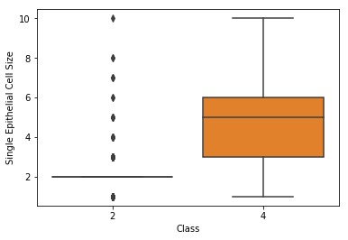

```python
sns.boxplot(x = "Class", y = "Single Epithelial Cell Size", data = bc)
plt.show()
# Class 4 has higher Single Epithelial Cell Size
```

### Class 4 appears to be more fatal in comparison to Class 02

```python
# Label encoding
from sklearn.preprocessing import LabelEncoder
```

```python
le = LabelEncoder()
```

```python
y = le.fit_transform(bc.Class)
```

```python
bc.head()
```

|  | ID | ClumpThickness | Cell Size | Cell Shape | Marginal Adhesion | Single Epithelial Cell Size | Bare Nuclei | Normal Nucleoli | Bland Chromatin | Mitoses | Class |
| --- | --- | --- | --- | --- | --- | --- | --- | --- | --- | --- | --- |
| 0 | 1000025 | 5 | 1 | 1 | 1 | 2 | 1 | 3 | 1 | 1 | 2 |
| 1 | 1002945 | 5 | 4 | 4 | 5 | 7 | 10 | 3 | 2 | 1 | 2 |
| 2 | 1015425 | 3 | 1 | 1 | 1 | 2 | 2 | 3 | 1 | 1 | 2 |
| 3 | 1016277 | 6 | 8 | 8 | 1 | 3 | 4 | 3 | 7 | 1 | 2 |
| 4 | 1017023 | 4 | 1 | 1 | 3 | 2 | 1 | 3 | 1 | 1 | 2 |

### Apply Support vectors without Scaling the Dataset

```python
from sklearn.cross_validation import train_test_split
```

```python
xtrain,xtest,ytrain,ytest = train_test_split(bc.drop("Class", axis = 1),y,
                                             test_size = 0.30, random_state = 1)
```

```python
svm = SVC()
```

```python
xtrain.info()
```

[output not shown]

```python
bc.isnull().sum()
```

[output not shown]

```python
print(sum(bc["Bare Nuclei"]=="?"))
print("\n")
print(bc["Bare Nuclei"].describe())
```

[output not shown]

```python
bc["Bare Nuclei"].value_counts()
```

[output not shown]

```python
# Replacing Question Mark with Mode
bc["Bare Nuclei"] = bc["Bare Nuclei"].replace(to_replace = "?",
                                             value = 1)
```

```python
bc.info()
```

```
<class 'pandas.core.frame.DataFrame'>
RangeIndex: 699 entries, 0 to 698
Data columns (total 11 columns):
ID                             699 non-null int64
ClumpThickness                 699 non-null int64
Cell Size                      699 non-null int64
Cell Shape                     699 non-null int64
Marginal Adhesion              699 non-null int64
Single Epithelial Cell Size    699 non-null int64
Bare Nuclei                    699 non-null object
Normal Nucleoli                699 non-null int64
Bland Chromatin                699 non-null int64
Mitoses                        699 non-null int64
Class                          699 non-null int64
dtypes: int64(10), object(1)
memory usage: 60.1+ KB
```